# Pleading vs Practice

Lincoln Mullen

August 10, 2016

In this notebook we are looking at the subjects and titles applied to the US items in the Making of Modern Law. The aim is to chart the trends in terms such as “practice” and “pleading.”

Beginning with the subjects: There are two kinds of subject tags applied in the MoML metadata: Library of Congress subject headings, and categories which must have been assigned by Gale. Here are two tables with the top twenty subjects, with counts of how many items have been assigned that subject.

```r
us_subjects_moml <- us_subjects %>%
  filter(subject_source == "MOML",
         subject != "US") %>%
  distinct(document_id, subject)
us_subjects_moml %>%
  count(subject) %>%
  arrange(desc(n)) %>%
  mutate(percent = round(n / nrow(us_items), 3)) %>%
  head(20)
```

```
# A tibble: 20 x 3
                                            subject     n percent
                                              <chr> <int>   <dbl>
1                                    Procedural Law  1842   0.167
2                                Constitutional Law   935   0.085
3                                   General Studies   911   0.082
4                                         Biography   864   0.078
5                                      Criminal Law   823   0.074
6                                     Real Property   679   0.061
7                       Taxation and Public Finance   583   0.053
8                         Politics &amp; Government   538   0.049
9                             Business Associations   524   0.047
10 Administration of Justice and Administrative Law   519   0.047
11                                  Civil Procedure   509   0.046
12                        Administration of Justice   489   0.044
13                                         Taxation   479   0.043
14                                   Commercial Law   460   0.042
15                         Practice &amp; Procedure   453   0.041
16               Constitutional Law: Special Topics   384   0.035
17                                     Corporations   378   0.034
18                                           Equity   376   0.034
19                                     Business Law   375   0.034
20                                         Evidence   332   0.030
```

```r
us_subjects_loc <- us_subjects %>%
  filter(subject_source == "LOC")
us_subjects_loc %>%
  count(subject) %>%
  arrange(desc(n)) %>%
  mutate(percent = round(n / nrow(us_items), 3)) %>%
  head(20)
```

```
# A tibble: 20 x 3
                                          subject     n percent
                                            <chr> <int>   <dbl>
1                            Law -- United States   262   0.024
2                 Evidence (Law) -- United States   226   0.020
3                Corporation law -- United States   217   0.020
4        United States -- Politics and government   177   0.016
5                         Courts -- United States   164   0.015
6             United States -- Constitutional law   160   0.014
7                      Contracts -- United States   159   0.014
8                  Real property -- United States   157   0.014
9                    Forms (Law) -- United States   156   0.014
10               Civil procedure -- United States   151   0.014
11 Equity pleading and procedure -- United States   147   0.013
12            Constitutional law -- United States   138   0.012
13                  Criminal law -- United States   124   0.011
14                    Bankruptcy -- United States   123   0.011
15                Commercial law -- United States   122   0.011
16 Equity pleading and procedure -- Great Britain   119   0.011
17            Civil procedure -- New York (State)   118   0.011
18                      Pleading -- United States   118   0.011
19            Criminal procedure -- United States   117   0.011
20                        Equity -- United States   114   0.010
```

The MoML subjects are much broader than the LoC subjects, but even so, in both cases the subjects are relatively diffuse, with all but the most commonly used subjects accounting for only a few percentage points.

Let’s see all the LoC subjects that contain “practice,” “procedure”, or “pleading.”

```r
us_subjects_loc %>%
  count(subject) %>%
  arrange(desc(n)) %>%
  mutate(percent = round(n / nrow(us_items), 3)) %>%
  filter(str_detect(subject, regex("practice|procedure|pleading",
                                   ignore_case = TRUE))) %>%
  head(20)
```

```
# A tibble: 20 x 3
                                             subject     n percent
                                               <chr> <int>   <dbl>
1                   Civil procedure -- United States   151   0.014
2     Equity pleading and procedure -- United States   147   0.013
3     Equity pleading and procedure -- Great Britain   119   0.011
4                Civil procedure -- New York (State)   118   0.011
5                          Pleading -- United States   118   0.011
6                Criminal procedure -- United States   117   0.011
7                          Pleading -- Great Britain    74   0.007
8                   Civil procedure -- Great Britain    55   0.005
9                    Trial practice -- United States    53   0.005
10                   Civil procedure -- Pennsylvania    34   0.003
11                 Code pleading -- New York (State)    33   0.003
12      Probate law and practice -- New York (State)    32   0.003
13                    Code pleading -- United States    31   0.003
14 Equity pleading and procedure -- New York (State)    29   0.003
15               Criminal procedure -- Great Britain    26   0.002
16                           Civil procedure -- Ohio    22   0.002
17         Probate law and practice -- Massachusetts    21   0.002
18      Civil procedure -- New York (State) -- Forms    19   0.002
19         Probate law and practice -- United States    19   0.002
20                  Procedure (Law) -- United States    19   0.002
```

We will get better results if we keep just the first part of the subject.

```r
first_subject <- function(x) {
  str_split_fixed(x, " -- ", 3)[,1, drop = TRUE]
}
us_subjects_loc %>%
  mutate(subject = first_subject(subject)) %>%
  count(subject) %>%
  arrange(desc(n)) %>%
  mutate(percent = round(n / nrow(us_items), 3)) %>%
  filter(str_detect(subject, regex("practice|procedure|pleading",
                                   ignore_case = TRUE))) %>%
  head(20)
```

```
# A tibble: 20 x 3
                           subject     n percent
                             <chr> <int>   <dbl>
1                  Civil procedure   567   0.051
2    Equity pleading and procedure   406   0.037
3                         Pleading   317   0.029
4               Criminal procedure   248   0.022
5         Probate law and practice   191   0.017
6                    Code pleading   107   0.010
7                   Trial practice    73   0.007
8              Appellate procedure    65   0.006
9                  Procedure (Law)    48   0.004
10          Parliamentary practice    29   0.003
11                 Practice of law    17   0.002
12                 Patent practice     4   0.000
13        Administrative procedure     2   0.000
14    Defense (Criminal procedure)     2   0.000
15                     Malpractice     2   0.000
16  Sentences (Criminal procedure)     2   0.000
17            Trials (Malpractice)     2   0.000
18            Appellate procedures     1   0.000
19      Auditors (Civil procedure)     1   0.000
20 Citizen suits (Civil procedure)     1   0.000
```

We want to get a sense of the relative change in certain terms over time.

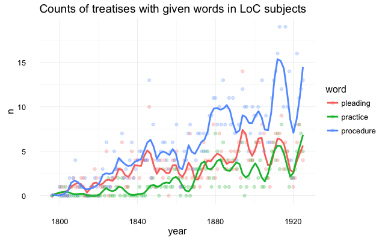

```r
items_per_year <- us_items %>%
  mutate(year = year(publication_date)) %>%
  count(year) %>%
  rename(total = n)
subject_counts_by_year <- us_items %>%
  mutate(year = year(publication_date)) %>%
  left_join(us_subjects_loc, by = "document_id") %>%
  mutate(subject = first_subject(subject)) %>%
  group_by(document_id) %>%
  mutate(practice = any(str_detect(subject, fixed("practice", ignore_case = TRUE))),
         pleading = any(str_detect(subject, fixed("pleading", ignore_case = TRUE))),
         procedure = any(str_detect(subject, fixed("procedure", ignore_case = TRUE)))) %>%
  ungroup() %>%
  distinct(document_id, year, practice, pleading, procedure) %>%
  group_by(year) %>%
  summarize(practice = sum(practice),
            pleading = sum(pleading),
            procedure = sum(procedure)) %>%
  gather(word, n, -year) %>%
  left_join(items_per_year, by = "year") %>%
  mutate(percentage = n / total) %>%
  filter(year > 1790,
         year < 1926)
ggplot(subject_counts_by_year, aes(x = year, y = n, color = word)) +
  geom_point(alpha = 0.25) +
  geom_smooth(span = 0.1, se = FALSE) +
  theme_minimal() +
  labs(title = "Counts of treatises with given words in LoC subjects")
```

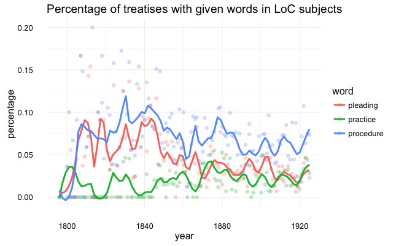

```r
ggplot(subject_counts_by_year, aes(x = year, y = percentage, color = word)) +
  geom_point(alpha = 0.25) +
  geom_smooth(span = 0.1, se = FALSE) +
  theme_minimal() +
  labs(title = "Percentage of treatises with given words in LoC subjects")
```

We also want to see the trend in those terms in the titles of treatises.

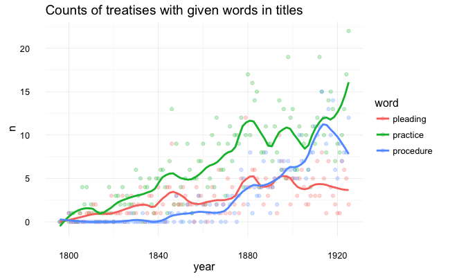

```r
words_in_titles_by_year <- us_items %>%
  mutate(year = year(publication_date)) %>%
  group_by(document_id) %>%
  mutate(practice = any(str_detect(title_full,
                                   fixed("practice", ignore_case = TRUE))),
         pleading = any(str_detect(title_full,
                                   fixed("pleading", ignore_case = TRUE))),
         procedure = any(str_detect(title_full,
                                    fixed("procedure", ignore_case = TRUE)))) %>%
  ungroup() %>%
  distinct(document_id, year, practice, pleading, procedure) %>%
  group_by(year) %>%
  summarize(practice = sum(practice),
            pleading = sum(pleading),
            procedure = sum(procedure)) %>%
  gather(word, n, -year) %>%
  left_join(items_per_year, by = "year") %>%
  mutate(percentage = n / total) %>%
  filter(year > 1790,
         year < 1926)
ggplot(words_in_titles_by_year, aes(x = year, y = n, color = word)) +
  geom_point(alpha = 0.25) +
  geom_smooth(span = 0.2, se = FALSE) +
  theme_minimal() +
  labs(title = "Counts of treatises with given words in titles")
```

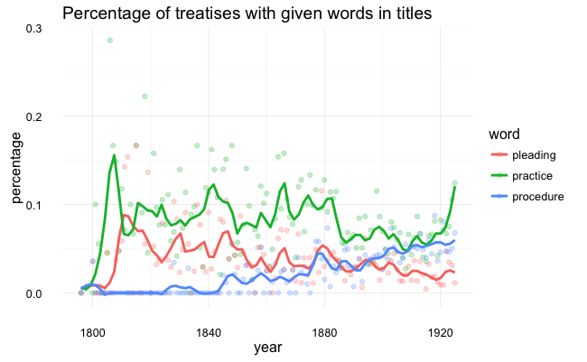

```r
ggplot(words_in_titles_by_year, aes(x = year, y = percentage, color = word)) +
  geom_point(alpha = 0.25) +
  geom_smooth(span = 0.1, se = FALSE) +
  theme_minimal() +
  labs(title = "Percentage of treatises with given words in titles")
```

Clean up the chart of titles.

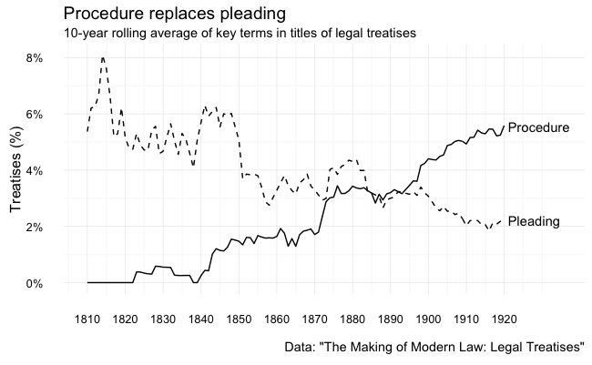

```r
roll_period <- 10
words_in_titles_by_year %>%
  filter(word != "practice",
         year >= 1800) %>%
  mutate(rolling_n = roll_mean(n, n = roll_period, align = "center", fill = NA_real_),
         rolling_total = roll_mean(total, n = roll_period, align = "center", fill = NA_real_),
         rolling_percentage = rolling_n / rolling_total) %>%
  filter(year <= 1920) %>%
  ggplot(aes(x = year, y = rolling_percentage, linetype = word)) +
  geom_line() +
  theme_minimal() +
  scale_x_continuous(name = "", limits = c(1810, 1935),
                     breaks = seq(1810, 1920, by = 10)) +
  scale_y_continuous(name = "Treatises (%)", labels = scales::percent) +
  scale_linetype_manual(values = c(2, 1)) +
  guides(color = FALSE, linetype = FALSE) +
  labs(title = "Procedure replaces pleading",
       subtitle = "10-year rolling average of key terms in titles of legal treatises",
       caption = 'Data: "The Making of Modern Law: Legal Treatises"') +
  annotate("text", x = 1921, y = 0.0555, hjust = 0, label = "Procedure") +
  annotate("text", x = 1921, y = 0.0220, hjust = 0, label = "Pleading")
```